# Model comparison using rjmcmc & gamma prior on B

Bayes Factor of compared models determined

### Contents

1. **Part I: RJMCMC - $exp(1)$ prior on $\beta$**
1. Data
- Data simulated using the Super Spreading Events model $(\alpha, \beta, \gamma)$. Four datasets simulated - small & large outbreaks.
- Data simulated using the Baseline model of a regular events spreading model $(\alpha)$. Two datasets simulated.
2. RJMCMC
- RJMCMC implemented, jumping between the SSE and baseline model.
- Bayes Factor between the two models calculated
2. **Part II: RJMCMC - $\Gamma(2, 1/2)$ prior on $\beta$**
- The steps are repeated as in part I with the exception of a $\Gamma(2, 1/2)$ prior on $\beta$
- Identical datasets are used

### Background

RJMCMC was implemented whereby the algorithm jumped between the Baseline model $M_1$ of an epidemic with regular spreading events $(\alpha)$ and the Super Spreading Events (SSE) model $(\alpha, \beta, \gamma)$ which has both regular spreading events with rate $\alpha$ and super spreading events with rate $\beta$ and multiplicative factor $\gamma$.

### Bayes Factor

Bayesian model comparison is a method of model selection based on Bayes factors. The aim of the Bayes factor is to quantify the support for one model over another, e.g model $M_1$ over model $M_2$. The Bayes Factor BF is as follows;
$$BF = \dfrac{P(D|M_1)}{P(D|M_2)} = \dfrac{\dfrac{P(M_1|D)P(D)}{P(M_1)}}{\dfrac{P(M_2|D)P(D)}{P(M_2)}} = \dfrac{P(M_1|D)}{P(M_2 | D)}$$
when $P(M_1) == P(M_2)$, otherwise
$$BF = \dfrac{P(D|M_1)}{P(D|M_2)} = \dfrac{\dfrac{P(M_1|D)}{P(M_1)}}{\dfrac{P(M_2|D)}{P(M_2)}} = \dfrac{P(M_1|D)}{P(M_1)} \cdot \dfrac{P(M_2)}{P(M_2|D)}$$
where $P(D|M_1)$ is the model evidence, specifically the marginal likelihood integrand;
$$P(D|M_1) = \int P(D \hspace{1 mm}|\hspace{1 mm} M_1, \theta) \hspace{1 mm} P(\hspace{1 mm}\theta \hspace{1 mm}| M_1) \hspace{1 mm}d \theta$$
and the first term in the integrand $P(D \hspace{1 mm}|\hspace{1 mm} M_1, \theta)$ is the likelihood and the second term $P(\hspace{1 mm}\theta \hspace{1 mm}| M_1)$ is the prior on the model parameter $\theta$.

#### Interpretation of the Bayes Factor results

A Bayes Factor > 1 signifies that $M_1$ is more strongly supported by the data under consideration than $M_2$. Harold Jefferys gave a scale of interpretation of the Bayes Factor;

| Bayes Factor | Bayes Factor equivalence | Evidence Strength |
| --- | --- | --- |
| < 10^0 | < 1 | Negative (supports M_2) |
| [10^0, 10^1/2] | [1, 3.16] | Weak evidence |
| [10^1/2, 10^1] | [3.16, 10] | Substantial |
| [10^1, 10^3/2] | [10, 31.62] | Strong |
| [10^3/2, 10^2] | [31.62, 100] | Very strong |
| > 10^2 | > 100 | Decisive |

#### Bayes Factor Results

In this particular setting in which the Baseline model $\alpha$ and SSE model $(\alpha, \beta, \gamma)$ are compared, the Bayes factor is calculated as;

$$\dfrac{Proportion \hspace{1 mm}of \hspace{1 mm} \beta \hspace{1 mm} mcmc \hspace{1 mm} samples == 0}{Proportion \hspace{1 mm}of \hspace{1 mm} \beta \hspace{1 mm} mcmc \hspace{1 mm} samples != 0}$$

| Epidemic Data | Max daily infection count | Bayes Factor exp(beta; 1) | Bayes Factor, Gamma(2, 1/2) |
| --- | --- | --- | --- |
| SSE - dies out | 2 | 7.741 | 9.846 |
| SSE spreads | 55 | 0 | 0 |
| SS spreads | 340 | 0 | 0 |
| SSE - dies out | 2 | 5.481 | 5.711 |
| Base - spreads | 65 | 6.968 | 7.19 |
| Base - spreads | 45 | 2.2546 | 2.701 |

The mcmc plots of all aformentioned iterations are as below.

## Part I: RJMCMC between Base model & SSE Model - exp(1) prior used for beta

[figure not shown]

### Part 2: Gamma Prior on Beta

A gamma prior, $\Gamma(\beta; k, \theta)$ on beta was also trialed whereby $k$ determines the shape of the distribution and $\theta$ governs the scale. The gamma distribution function is as follows;

$$\Gamma(\beta; k, \theta) = \dfrac{1}{\Gamma(k) \cdot \theta^k}\cdot \beta^{(k-1)} \cdot e^{\dfrac{-\beta}{\theta}}$$

A range of gamma priors on beta are used including a $\Gamma\hspace{1mm}(\beta; \hspace{1mm}2, \hspace{1mm} 2.5)$, $\Gamma\hspace{1mm}(\beta; \hspace{1mm}2.5, \hspace{1mm} 2)$ and a $\Gamma \hspace{1mm}(\beta; \hspace{1mm} 3, \hspace{1mm} 2)$ Each have a mean of $k \cdot \theta$. A $\Gamma\hspace{1mm}(\beta; \hspace{1mm}2, \hspace{1mm} 2.5)$, is as follows;

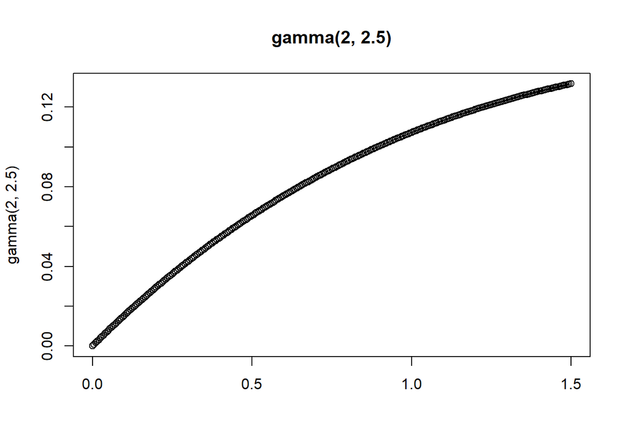

A $\Gamma\hspace{1mm}(\beta; \hspace{1mm}3, \hspace{1mm} 2)$,;

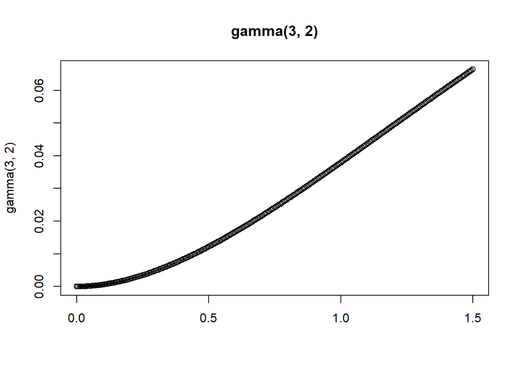

And a $\Gamma\hspace{1mm}(\beta; \hspace{1mm}3, \hspace{1mm} 3)$,;

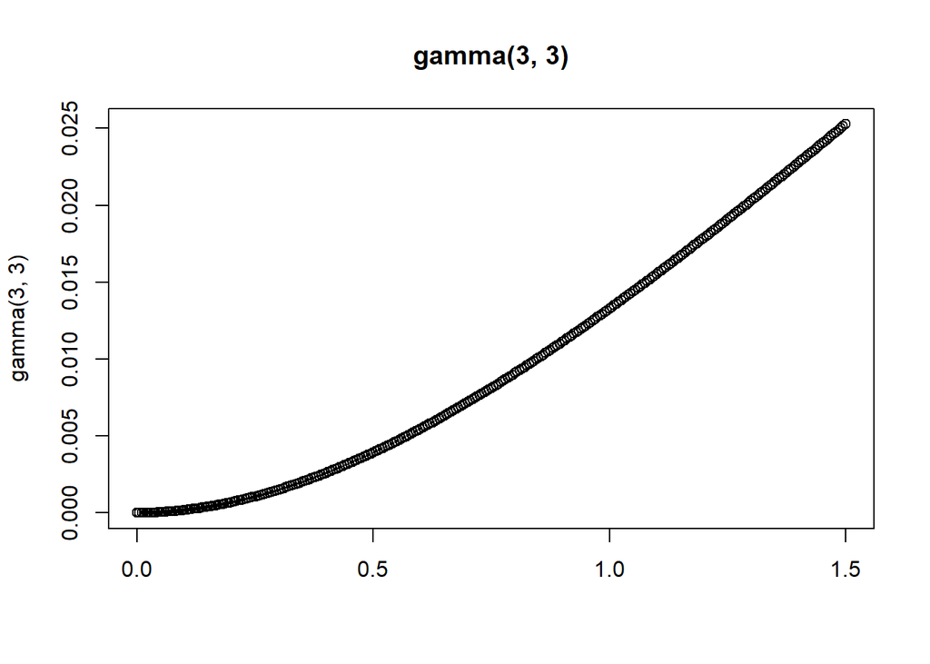

And a $\Gamma\hspace{1mm}(\beta; \hspace{1mm}4, \hspace{1mm} 4)$,;

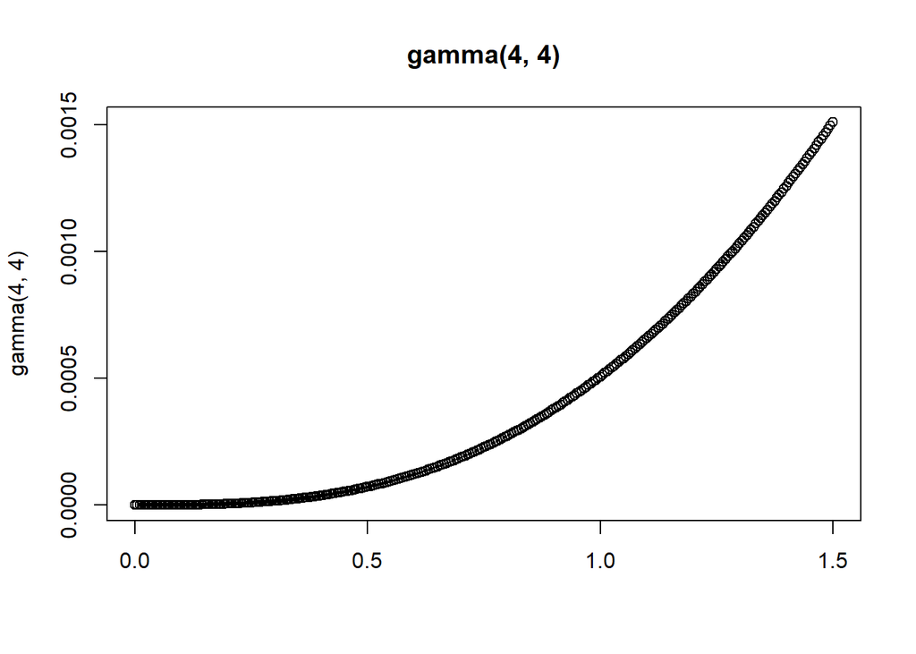

In the Metropolis acceptance step, the logs of all quantities are determined and evaluating $log\hspace{1mm}( \Gamma\hspace{1mm}(\beta; \hspace{1mm} k, \hspace{1mm} \theta))$ gives;

$$log\bigg( \dfrac{1}{\Gamma(k) \cdot \theta^k}\cdot \beta^{(k-1)} \cdot e^{\dfrac{-\beta}{\theta}} \bigg)$$
=
$$\dfrac{1}{log\Gamma(k)\cdot klog(\theta)} \cdot (k-1) \cdot log(\beta) \cdot \dfrac{-\beta}{\theta}$$

### Gamma Prior $\Gamma$($\beta$; 2, 2.5)

#### Model Comparison - SSE data I